# Reproductible Research : Week 2

JULIA F

22 juillet 2017

## Loading and preprocessing the data

### 1. Code for reading in the dataset and/or processing the data

```r
dfRaw <- read.csv(file.path("./activity.csv"), sep = ",", header = TRUE, na.strings = "NA")
df <- subset.data.frame(dfRaw, steps != "NA")   # Remove lines with NA values. A bad thing for next questions ?
```

## What is mean total number of steps taken per day?

### 1. Make a histogram of the total number of steps taken each day

[figure not shown]

```r
# Aggregate steps by day
totalStepsByDay <- aggregate.data.frame(df$steps, by=list(dateMesure = df$date), FUN = "sum")
totalStepsByDay <- rename(totalStepsByDay, totalSteps = x)

# Display total steps by day
with(totalStepsByDay,
   histogram(x = totalSteps,
      breaks = 20,
      xlab = "Date",
      ylab = "Total steps",
      main = "Total steps by day",
      col=rgb(0,0,1,0.5)
   )
)
```

```r
# Calculate the mean and median of the total number of steps taken per day
meanTotalSteps   <- mean(totalStepsByDay$totalSteps)
medianTotalSteps <- median(totalStepsByDay$totalSteps)
```

## What is the average daily activity pattern?

### 1. Calculate and report the mean of the number of steps by interval of the day

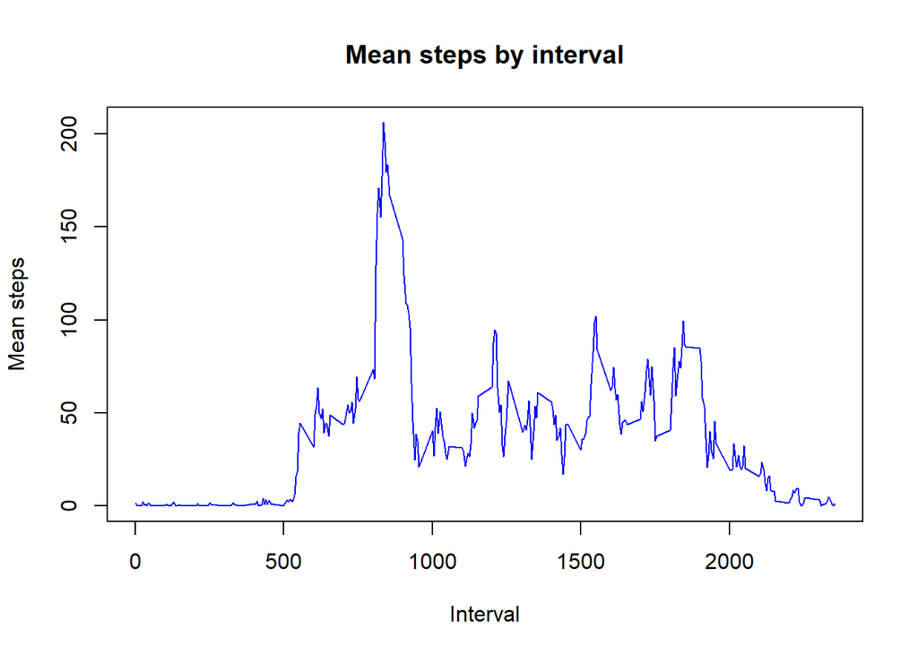

```r
meanStepsByInterval  <- aggregate.data.frame(df$steps, by=list(interval = df$interval), FUN = "mean")
meanStepsByInterval  <- rename(meanStepsByInterval, meanSteps = x)

plot(
   x = meanStepsByInterval$interval,
   y = meanStepsByInterval$meanSteps,
   type = "l",
   main = "Mean steps by interval", xlab = "Interval", ylab = "Mean steps", col = "blue"
)
```

### 2. Which 5-minute interval, on average across all the days in the dataset, contains the maximum number of steps?

```r
maxMeanStepsByInterval <- max(meanStepsByInterval$meanSteps)
orderedMeans <- arrange(meanStepsByInterval, desc(meanSteps))
intervalWithMaxMean <- orderedMeans$interval[1]
```

The maximum on average across all the days is 206.1698113 .

This maximum is get for the interval 835 .

## Imputing missing values

### 1. Calculate and report the total number of missing values in the dataset (i.e. the total number of rows with NAs)

We need to reload data to recover NA lines

```r
df <- dfRaw
nbNA <- sum(is.na.data.frame(df$steps))
```

The number of NA values in the dataset is 2304 .

### 2. Devise a strategy for filling in all of the missing values in the dataset. The strategy does not need to be sophisticated

The selected method is to take the mean of the missing interval across all the days.

### 3. Create a new dataset that is equal to the original dataset but with the missing data filled in

```r
dfFilled <- df %>%
   inner_join(meanStepsByInterval, by = "interval") %>%  # Add a column with mean steps by interval across days
   mutate(filledSteps = if_else(is.na.data.frame(steps), as.integer(round(meanSteps)), steps) ) %>%
   select(steps = filledSteps, date, interval)
```

### 4. Make a histogram of the total number of steps taken each day and Calculate and report the mean and median total number of steps taken per day. Do these values differ from the estimates from the first part of the assignment? What is the impact of imputing missing data on the estimates of the total daily number of steps?

[figure not shown]

```r
# Aggregate steps by day
totalStepsByDay <- aggregate.data.frame(dfFilled$steps, by=list(dateMesure = dfFilled$date), FUN = "sum")
totalStepsByDay <- rename(totalStepsByDay, totalSteps = x)

# Display total steps by day
with(totalStepsByDay,
   histogram(x = totalSteps,
      breaks = 20,
      xlab = "Date",
      ylab = "Total steps",
      main = "Total steps by day",
      col=rgb(0,0,1,0.5)
   )
)
```

```r
# Calculate the mean and median of the total number of steps taken per day
meanTotalSteps   <- mean(totalStepsByDay$totalSteps)
medianTotalSteps <- median(totalStepsByDay$totalSteps)
```

**These values are not so different from the previous ones. NA values were precedently ignored, ans new ones are equals to the mean of sames intervals.**

## Are there differences in activity patterns between weekdays and weekends?

### 1. Create a new factor variable in the dataset with two levels – “weekday” and “weekend” indicating whether a given date is a weekday or weekend day

```r
dfFilled <- dfFilled %>%
   mutate(weekday =
             if_else(
                weekdays(as.Date(date)) == weekdays(as.Date("1970-01-03")) |
                weekdays(as.Date(date)) == weekdays(as.Date("1970-01-04")),
                "weekend", "weekday"
             )
          )
```

### 2. Make a panel plot containing a time series plot (i.e. type = “l”) of the 5-minute interval (x-axis) and the average number of steps taken, averaged across all weekday days or weekend days (y-axis)

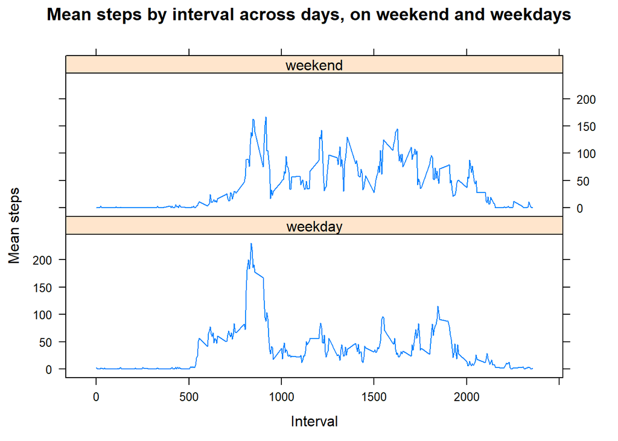

```r
# Calculate means of steps by interval across days
meanStepsByInterval  <- aggregate.data.frame(dfFilled$steps, by=list(interval = dfFilled$interval, weekday = dfFilled$weekday), FUN = "mean")
meanStepsByInterval  <- rename(meanStepsByInterval, meanSteps = x)

# Display histogram with these values, separate between weekdays and weekends
xyplot(
   meanSteps ~ interval | weekday,
   data = meanStepsByInterval,
   type = "l",
   layout = c(1,2),
   main = "Mean steps by interval across days, on weekend and weekdays",
   xlab = "Interval", ylab = "Mean steps")
```